# Fall 2021 R bootcamp

This content is based on [Datacamp’s](https://www.datacamp.com/) “Introduction to the tidyverse” course.

## Look at the `gapminder` dataset we just loaded

```r
head(gapminder)
```

```
## # A tibble: 6 x 6
##   country     continent  year lifeExp      pop gdpPercap
##   <fct>       <fct>     <int>   <dbl>    <int>     <dbl>
## 1 Afghanistan Asia       1952    28.8  8425333      779.
## 2 Afghanistan Asia       1957    30.3  9240934      821.
## 3 Afghanistan Asia       1962    32.0 10267083      853.
## 4 Afghanistan Asia       1967    34.0 11537966      836.
## 5 Afghanistan Asia       1972    36.1 13079460      740.
## 6 Afghanistan Asia       1977    38.4 14880372      786.
```

## Using pipes to explore, filter, arrange, and subset the data

### Subsetting the dataset with `filter()`

`filter()` selects certain rows based on one or more matching criteria

##### Filter the dataset by year

```r
# filter the dataset by year
gapminder %>%
  filter(year == 2007)
```

```
## # A tibble: 142 x 6
##    country     continent  year lifeExp       pop gdpPercap
##    <fct>       <fct>     <int>   <dbl>     <int>     <dbl>
##  1 Afghanistan Asia       2007    43.8  31889923      975.
##  2 Albania     Europe     2007    76.4   3600523     5937.
##  3 Algeria     Africa     2007    72.3  33333216     6223.
##  4 Angola      Africa     2007    42.7  12420476     4797.
##  5 Argentina   Americas   2007    75.3  40301927    12779.
##  6 Australia   Oceania    2007    81.2  20434176    34435.
##  7 Austria     Europe     2007    79.8   8199783    36126.
##  8 Bahrain     Asia       2007    75.6    708573    29796.
##  9 Bangladesh  Asia       2007    64.1 150448339     1391.
## 10 Belgium     Europe     2007    79.4  10392226    33693.
## # … with 132 more rows
```

##### Filter the dataset by country

```r
gapminder %>%
  filter(country == "United States")
```

```
## # A tibble: 12 x 6
##    country       continent  year lifeExp       pop gdpPercap
##    <fct>         <fct>     <int>   <dbl>     <int>     <dbl>
##  1 United States Americas   1952    68.4 157553000    13990.
##  2 United States Americas   1957    69.5 171984000    14847.
##  3 United States Americas   1962    70.2 186538000    16173.
##  4 United States Americas   1967    70.8 198712000    19530.
##  5 United States Americas   1972    71.3 209896000    21806.
##  6 United States Americas   1977    73.4 220239000    24073.
##  7 United States Americas   1982    74.6 232187835    25010.
##  8 United States Americas   1987    75.0 242803533    29884.
##  9 United States Americas   1992    76.1 256894189    32004.
## 10 United States Americas   1997    76.8 272911760    35767.
## 11 United States Americas   2002    77.3 287675526    39097.
## 12 United States Americas   2007    78.2 301139947    42952.
```

##### Filter the dataset by country and year

```r
gapminder %>%
  filter(country == "United States", year == 2007)
```

```
## # A tibble: 1 x 6
##   country       continent  year lifeExp       pop gdpPercap
##   <fct>         <fct>     <int>   <dbl>     <int>     <dbl>
## 1 United States Americas   2007    78.2 301139947    42952.
```

### Sorting with `arrange()`

##### Sort entire dataset by life expectancy

```r
gapminder %>%
  arrange(lifeExp)
```

```
## # A tibble: 1,704 x 6
##    country      continent  year lifeExp     pop gdpPercap
##    <fct>        <fct>     <int>   <dbl>   <int>     <dbl>
##  1 Rwanda       Africa     1992    23.6 7290203      737.
##  2 Afghanistan  Asia       1952    28.8 8425333      779.
##  3 Gambia       Africa     1952    30    284320      485.
##  4 Angola       Africa     1952    30.0 4232095     3521.
##  5 Sierra Leone Africa     1952    30.3 2143249      880.
##  6 Afghanistan  Asia       1957    30.3 9240934      821.
##  7 Cambodia     Asia       1977    31.2 6978607      525.
##  8 Mozambique   Africa     1952    31.3 6446316      469.
##  9 Sierra Leone Africa     1957    31.6 2295678     1004.
## 10 Burkina Faso Africa     1952    32.0 4469979      543.
## # … with 1,694 more rows
```

##### Sort entire dataset, in descending order, by life expectancy

```r
gapminder %>%
  arrange(desc(lifeExp))
```

```
## # A tibble: 1,704 x 6
##    country          continent  year lifeExp       pop gdpPercap
##    <fct>            <fct>     <int>   <dbl>     <int>     <dbl>
##  1 Japan            Asia       2007    82.6 127467972    31656.
##  2 Hong Kong, China Asia       2007    82.2   6980412    39725.
##  3 Japan            Asia       2002    82   127065841    28605.
##  4 Iceland          Europe     2007    81.8    301931    36181.
##  5 Switzerland      Europe     2007    81.7   7554661    37506.
##  6 Hong Kong, China Asia       2002    81.5   6762476    30209.
##  7 Australia        Oceania    2007    81.2  20434176    34435.
##  8 Spain            Europe     2007    80.9  40448191    28821.
##  9 Sweden           Europe     2007    80.9   9031088    33860.
## 10 Israel           Asia       2007    80.7   6426679    25523.
## # … with 1,694 more rows
```

##### Filter for year 1957, then sort in descending order by population size

```r
gapminder %>%
  filter(year == 1957) %>%
  arrange(desc(pop))
```

```
## # A tibble: 142 x 6
##    country        continent  year lifeExp       pop gdpPercap
##    <fct>          <fct>     <int>   <dbl>     <int>     <dbl>
##  1 China          Asia       1957    50.5 637408000      576.
##  2 India          Asia       1957    40.2 409000000      590.
##  3 United States  Americas   1957    69.5 171984000    14847.
##  4 Japan          Asia       1957    65.5  91563009     4318.
##  5 Indonesia      Asia       1957    39.9  90124000      859.
##  6 Germany        Europe     1957    69.1  71019069    10188.
##  7 Brazil         Americas   1957    53.3  65551171     2487.
##  8 United Kingdom Europe     1957    70.4  51430000    11283.
##  9 Bangladesh     Asia       1957    39.3  51365468      662.
## 10 Italy          Europe     1957    67.8  49182000     6249.
## # … with 132 more rows
```

### Changing and adding variables with `mutate()`

##### Calculate and sort the dataset by total GDP

We’ve added a new column, `gdp`, to hold the total GDP calculation

```r
gapminder %>%
  mutate(gdp = gdpPercap * pop) %>%
  filter(year == 2007) %>%
  arrange(desc(gdp))
```

```
## # A tibble: 142 x 7
##    country        continent  year lifeExp        pop gdpPercap     gdp
##    <fct>          <fct>     <int>   <dbl>      <int>     <dbl>   <dbl>
##  1 United States  Americas   2007    78.2  301139947    42952. 1.29e13
##  2 China          Asia       2007    73.0 1318683096     4959. 6.54e12
##  3 Japan          Asia       2007    82.6  127467972    31656. 4.04e12
##  4 India          Asia       2007    64.7 1110396331     2452. 2.72e12
##  5 Germany        Europe     2007    79.4   82400996    32170. 2.65e12
##  6 United Kingdom Europe     2007    79.4   60776238    33203. 2.02e12
##  7 France         Europe     2007    80.7   61083916    30470. 1.86e12
##  8 Brazil         Americas   2007    72.4  190010647     9066. 1.72e12
##  9 Italy          Europe     2007    80.5   58147733    28570. 1.66e12
## 10 Mexico         Americas   2007    76.2  108700891    11978. 1.30e12
## # … with 132 more rows
```

##### Create `gapminder_2007` data frame, which includes life expectancy in months (`lifeExpMonths`) for the year 2007

```r
gapminder_2007 <- gapminder %>%
    filter(year == 2007, continent == 'Asia') %>%
    mutate(lifeExpMonths = 12 * lifeExp) %>%
    arrange(desc(lifeExpMonths))
```

## Visualizing data with `ggplot2`

All `ggplot2` graphs consist of three elements:

1. data
2. aesthetic mapping (`aes()`)
3. one or more layers (`+`)

### Basic scatterplot with and without log scale

GDP varies by several [orders of magnitude](https://simple.wikipedia.org/wiki/Order_of_magnitude) so all of the countries with relatively low GDPs are piled up on the left side of the plot.

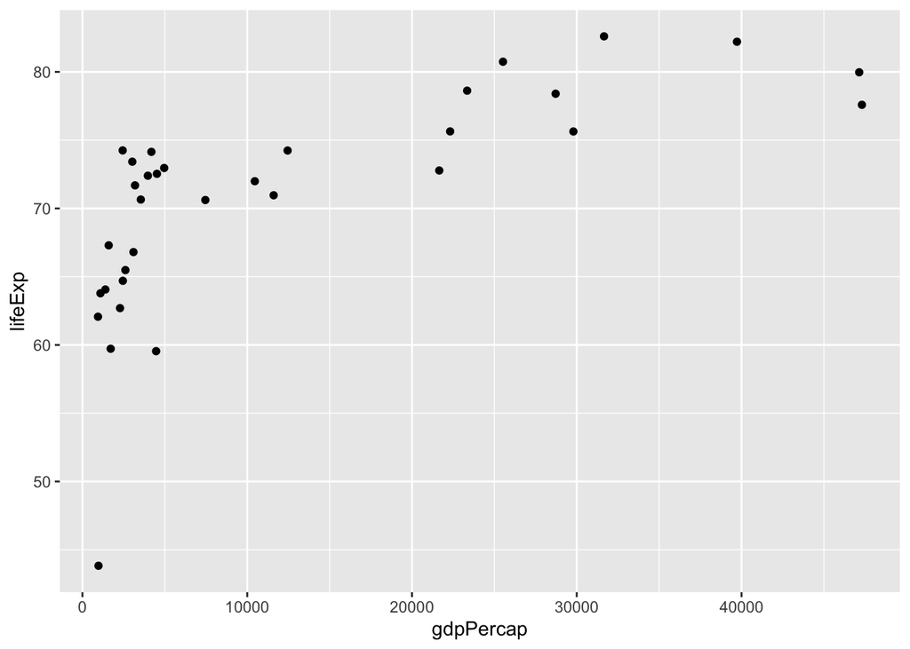

```r
ggplot(gapminder_2007, aes(x = gdpPercap, y = lifeExp)) +
  geom_point()
```

We can add a `scale_x_log10()` layer to apply a log10 transformation of `gdpPercap` to spread those out values out and linearize the relationship, making the data easier to visualize.

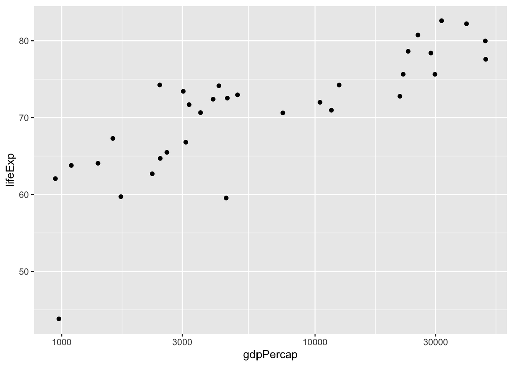

```r
ggplot(gapminder_2007, aes(x = gdpPercap, y = lifeExp)) +
  geom_point() +
  scale_x_log10()
```

### Adding aesthetics

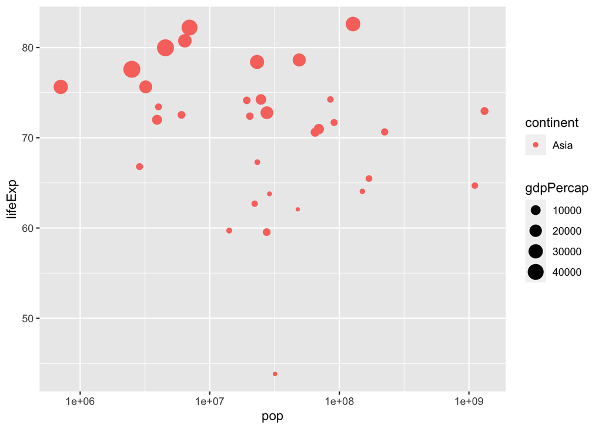

```r
ggplot(gapminder_2007, aes(x = pop, y = lifeExp, color = continent, size = gdpPercap)) +
  geom_point() +
  scale_x_log10()
```

### Faceting

Rather than looking at all of the data on the same plot, sometimes it’s useful to separate the data into multiple plots, so you can look at trends by continent, country, or year, for example.

#### Scatter plot comparing population size and life expectancy, faceted by continent

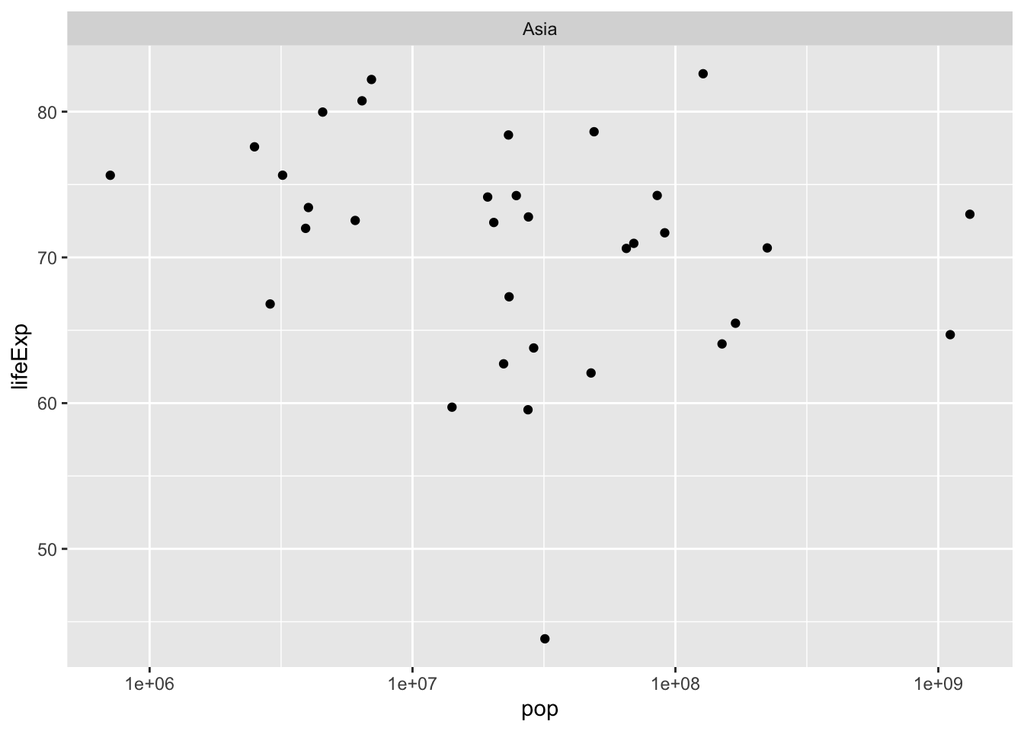

```r
ggplot(gapminder_2007, aes(x = pop, y = lifeExp)) +
  geom_point() +
  scale_x_log10() +
  facet_wrap(~ continent)
```

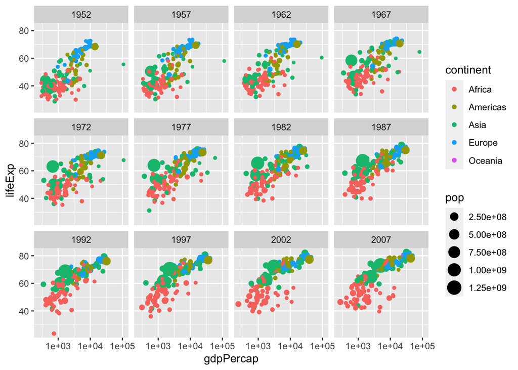

```r
ggplot(gapminder, aes(x = gdpPercap, y = lifeExp, color = continent, size = pop)) +
    geom_point() +
    scale_x_log10() +
    facet_wrap(~ year)
```

### Using `summarize()` to explore trends in the data

```r
gapminder %>%
  filter(year == 1957) %>%
  summarize(meanLifeExp = median(lifeExp),
            totalPop = sum(pop))
```

[output not shown]

#### What was the median life expectancy and maximum GDP per capita in 1957?

```r
gapminder %>%
    filter(year == 1957) %>%
    summarize(maxGdpPercap = max(gdpPercap), medianLifeExp = median(lifeExp))
```

```
## # A tibble: 1 x 2
##   maxGdpPercap medianLifeExp
##          <dbl>         <dbl>
## 1      113523.          48.4
```

### Using the `group_by()` function

```r
gapminder %>%
    group_by(year) %>%
    summarize(meanLifeExp = mean(lifeExp), totalPop = sum(pop))
```

```
## # A tibble: 12 x 3
##     year meanLifeExp   totalPop
##    <int>       <dbl>      <dbl>
##  1  1952        49.1 2406957150
##  2  1957        51.5 2664404580
##  3  1962        53.6 2899782974
##  4  1967        55.7 3217478384
##  5  1972        57.6 3576977158
##  6  1977        59.6 3930045807
##  7  1982        61.5 4289436840
##  8  1987        63.2 4691477418
##  9  1992        64.2 5110710260
## 10  1997        65.0 5515204472
## 11  2002        65.7 5886977579
## 12  2007        67.0 6251013179
```

#### What was the median life expectancy and maximum GDP per capita in each continent in 1957?

```r
gapminder %>%
    filter(year == 1957) %>%
    group_by(continent) %>%
    summarize(medianLifeExp = median(lifeExp), maxGdpPercap = max(gdpPercap))
```

```
## # A tibble: 5 x 3
##   continent medianLifeExp maxGdpPercap
##   <fct>             <dbl>        <dbl>
## 1 Africa             40.6        5487.
## 2 Americas           56.1       14847.
## 3 Asia               48.3      113523.
## 4 Europe             67.6       17909.
## 5 Oceania            70.3       12247.
```

```r
gapminder %>%
    group_by(year, continent) %>%
    summarize(meanLifeExp = mean(lifeExp), totalPop = sum(pop))
```

```
## # A tibble: 60 x 4
## # Groups:   year [12]
##     year continent meanLifeExp   totalPop
##    <int> <fct>           <dbl>      <dbl>
##  1  1952 Africa           39.1  237640501
##  2  1952 Americas         53.3  345152446
##  3  1952 Asia             46.3 1395357351
##  4  1952 Europe           64.4  418120846
##  5  1952 Oceania          69.3   10686006
##  6  1957 Africa           41.3  264837738
##  7  1957 Americas         56.0  386953916
##  8  1957 Asia             49.3 1562780599
##  9  1957 Europe           66.7  437890351
## 10  1957 Oceania          70.3   11941976
## # … with 50 more rows
```

## Plotting the results of `group_by()` and `summarize()`

### Create and save a new data frame based on summary statistics for life expectancy and GDP

```r
by_year <- gapminder %>%
  group_by(year) %>%
  summarize(medianLifeExp = median(lifeExp),
            maxGdpPercap = max(gdpPercap))
```

### Create a scatter plot showing the change in median life expectancy over time

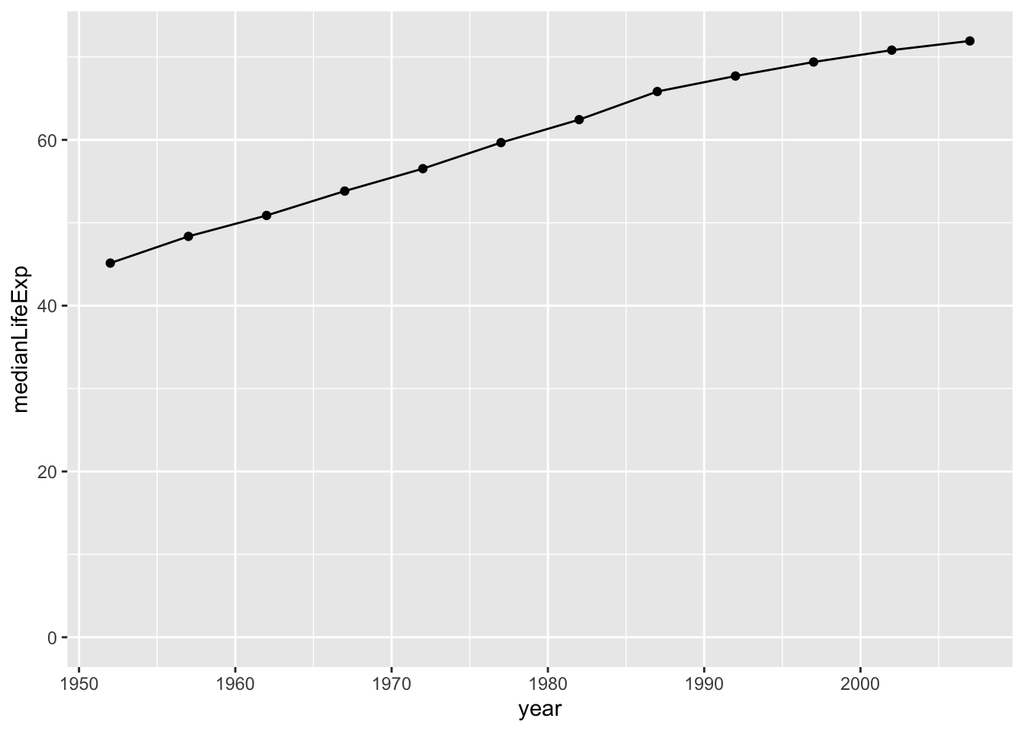

```r
ggplot(by_year, aes(x = year, y = medianLifeExp)) +
  geom_point() +
  geom_line() +           # add a line!
  expand_limits(y = 0)
```

### Create a data frame (`by_year_continent`) that summarizes median GDP per capita within each continent within each year

```r
by_year_continent <- gapminder %>%
    group_by(continent, year) %>%
    summarize(medianGdpPercap = median(gdpPercap))
```

### Plot the change in median GDP per capita in each continent over time

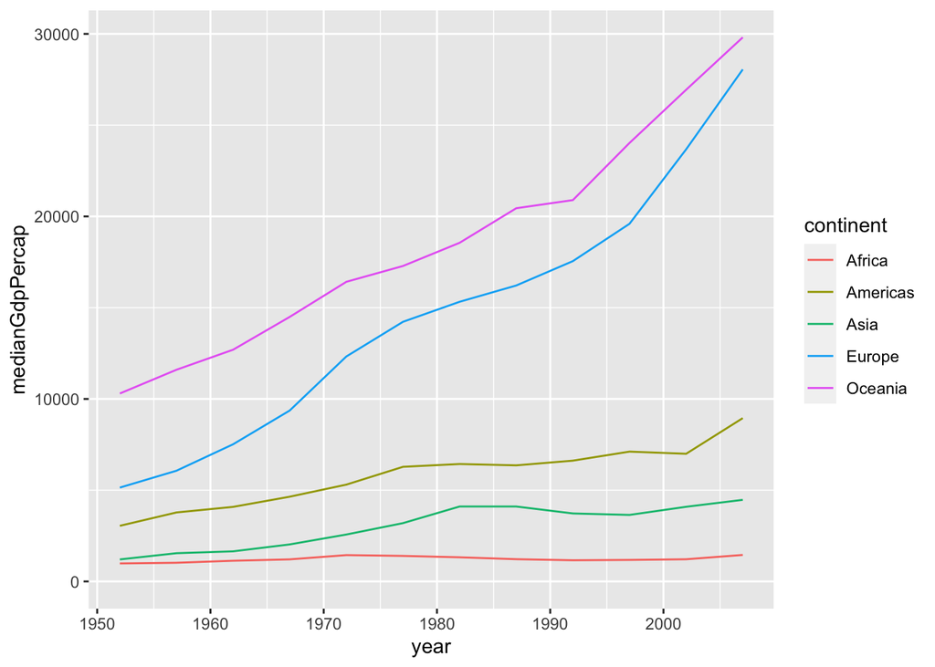

```r
ggplot(by_year_continent, aes(x = year, y = medianGdpPercap, color = continent)) +
  geom_line() +
  expand_limits(y = 0)
```

## Creating bar plots

### Create `by_continent` data frame with median per capita GDP in 1952

```r
by_continent <-gapminder %>%
    filter(year == 1952) %>%
    group_by(continent) %>%
    summarize(medianGdpPercap = median(gdpPercap))
```

#### Create a bar plot showing medianGdp by continent

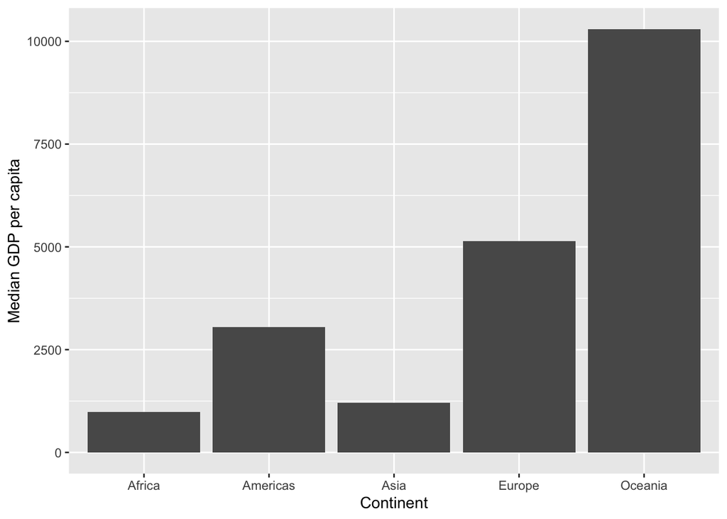

```r
ggplot(by_continent, aes(x = continent, y = medianGdpPercap)) +
  geom_col() +
  xlab("Continent") +
  ylab("Median GDP per capita")
```

## Visualizing distributions with histograms

### Create a data frame with populations in the millions for the year 2007

```r
gapminder_2007 <- gapminder %>%
  filter(year == 2007) %>%
  mutate(pop_by_mil = pop / 1000000)
```

### Make a histogram of country population in 2007

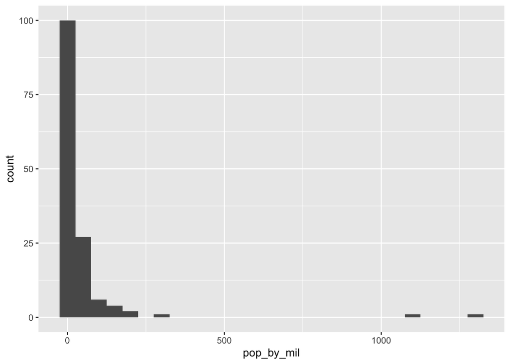

```r
ggplot(gapminder_2007, aes(x = pop_by_mil)) +
  geom_histogram(binwidth = 50)
```

### Make a histogram of country population in 2007 with X-axis on a log scale

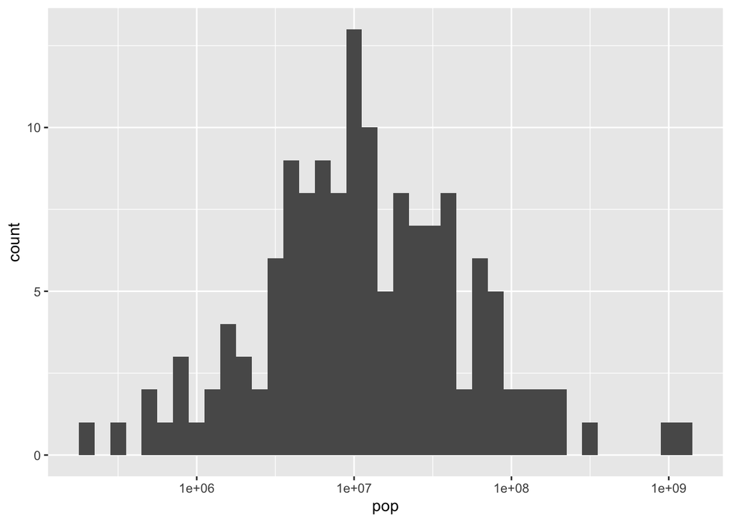

```r
ggplot(gapminder_2007, aes(x = pop)) +
  geom_histogram(binwidth = 0.1) +
  scale_x_log10()
```

## Comparing distributions with box plots

### Create a boxplot comparing GDP per capita among continents in 2007

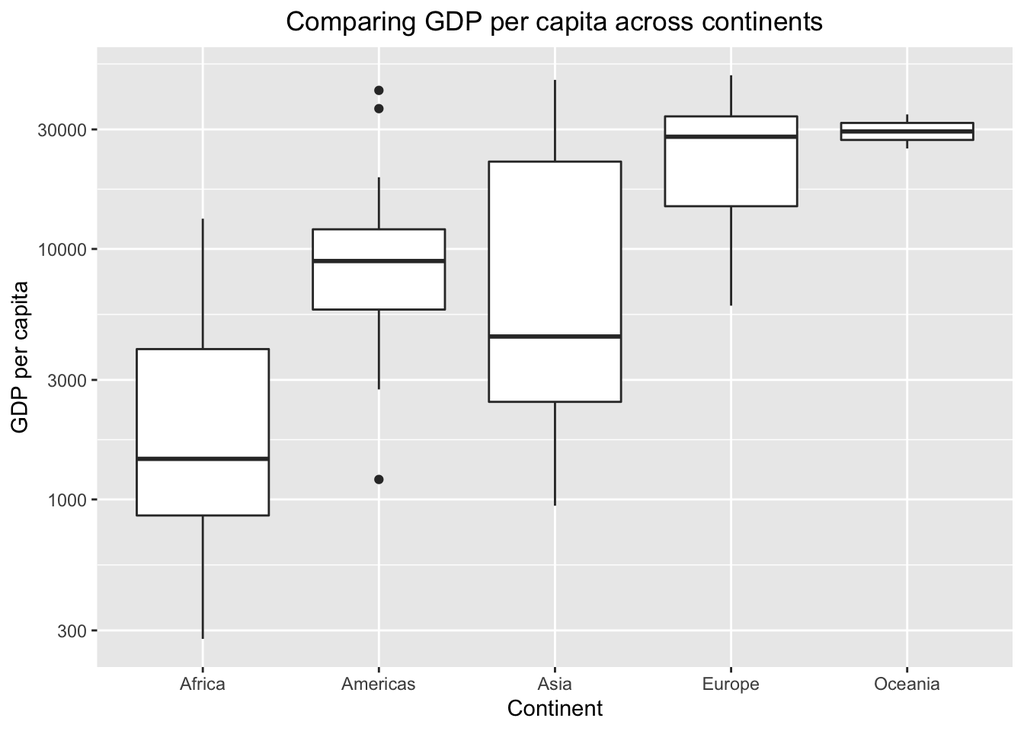

```r
ggplot(gapminder_2007, aes(x = continent, y = gdpPercap)) +
  geom_boxplot() +
  scale_y_log10() +
  xlab("Continent") +
  ylab("GDP per capita") +
  ggtitle("Comparing GDP per capita across continents") +
  theme(plot.title = element_text(hjust = 0.5))
```